# Clustering (Part I)

Ryan Miller

## Unsupervised Learning - Review

- In **supervised learning** we use a set of features, $\mathbf{X} = \{X_1,X_2,\ldots,X_p\}$, to model or predict an outcome variable $Y$
- In **unsupervised learning** we have $\mathbf{X} = \{X_1,X_2,\ldots,X_p\}$, but no natural outcome variable to model, instead the goal is to find hidden patterns or groups within the data

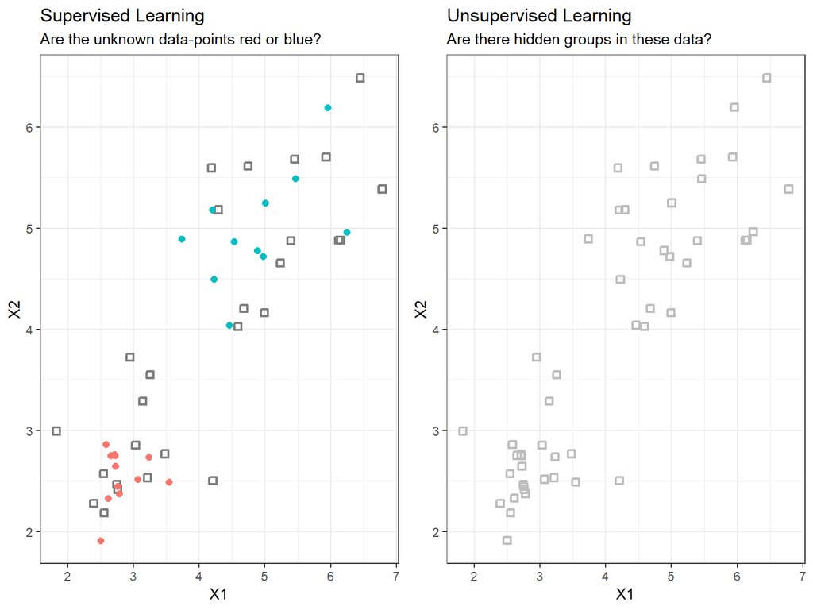

## Clustering vs. PCA

- Principal component analysis (PCA) is a tool used to discover hidden relationships among the variables (columns) of a dataset
  - PCA might suggest certain groups of variables might represent a single latent factor
- Clustering focuses on the data-points themselves (rows), suggesting that observations might be members of latent groups
- There are many types of clustering, we will focus on two broad categories:
  - **Partitional Clustering**: divides the data-points into non-overlapping subsets
  - **Hierarchical Clustering**: organizes the data-points into a nested subsets

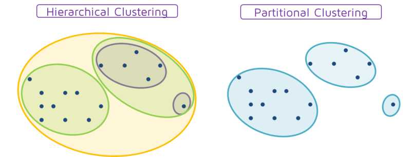

Image Source: [Quantdare](https://quantdare.com/hierarchical-clustering/)

## Clustering - A Simple Example

- The plot below provides a simple illustration of partitional clustering done on the `USArrests` dataset
  - States are grouped into non-overlapping subsets (red vs. blue) based upon their urban population and murder rate
- Cluster membership is estimated from the data
  - How might we determine if a certain state (say Virginia) is a “better fit” in Cluster #1 or Cluster #2?

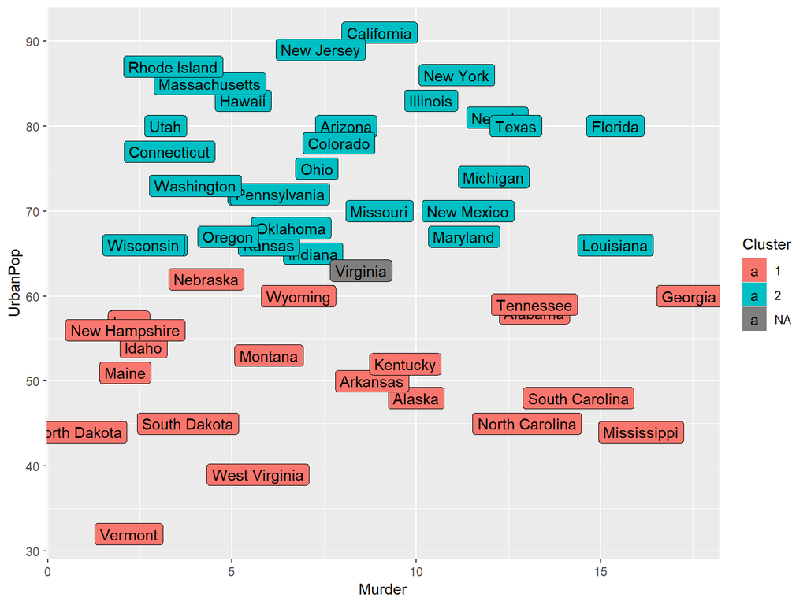

## Distance Matrices

- For data with $n$ observations, we can construct an $n$-by-$n$ matrix of the distances between each pair of data-points
- By visualizing the **distance matrix** we can discover trends in the data:

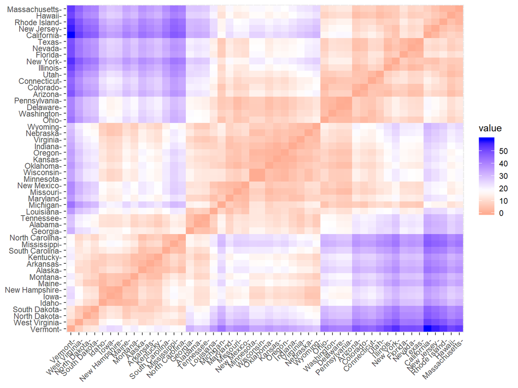

```r
USA2 <- select(USArrests, "UrbanPop", "Murder")
distance <- get_dist(USA2)
fviz_dist(distance)
```

## Standardization

- As was the case with PCA, the units of each variable can lead certain variables to disproportionately influence distance calculations
  - Because of this, we might consider **standardization** (re-scaling) the data
- We can see the impact this has on the `USArrests` data:

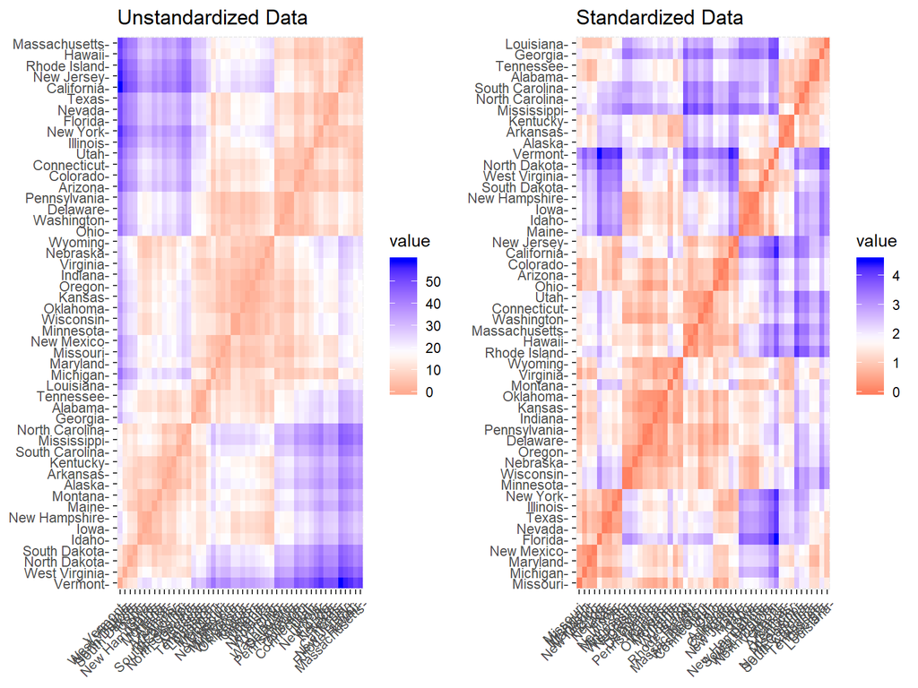

- In the distance matrix of the unstandardized data, the variable “UrbanPop” is dominating the distance calculation. Standardizing the data (using the `scale` function) leads to more balanced results

## Prototype-based Clustering

- So far we’ve established …
  - Good clusters should contain data-points that are “close” to each other and are far from data-points in other clusters
  - “Closeness” can be measured via Euclidean distance
- One approach to translating these two ideas into clusters is to introduce **prototypes*, or entities that define each cluster
  - For most applications, a prototype can be thought of as a central point representing a particular cluster
  - Prototypes may be an abstraction of the data (ie: the **centroid** or multi-dimensional mean), or a data-point itself (ie: the **medoid** or multi-dimensional median)

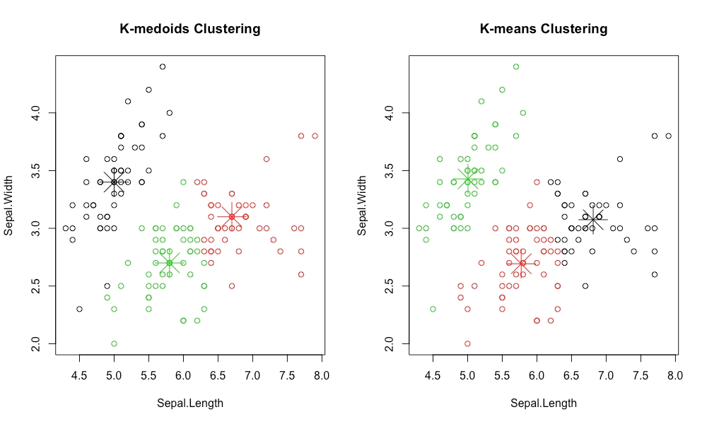

Image source: [Applied Unsupervised Learning with R](https://subscription.packtpub.com/book/big_data_and_business_intelligence/9781789956399/1/ch01lvl1sec08/introduction-to-k-medoids-clustering)

## $k$-means Clustering

- **k-means** clustering is a prototype-based partitional clustering method
- Let $\mu_k$ denote the centroid of $C_k$, the $k^{th}$ cluster, and let $x_i$ be the $i^{th}$ data-point in the $k^{th}$ cluster, then:
  $$\text{Total Withiness} = \sum_{k=1}^{k} W(C_k) = \sum_{k=1}^{k} \sum_{x_i \in C_k} (x_i - \mu_k)^2$$
- For a fixed $k$, the optimal cluster assignment minimizes *Total Withiness* (sometimes called the total within cluster sum of squares), this assignment defines the $k$-means clusters

## $k$-Means Clustering - Algorithm

1. Initialize $k$ centroids (typically at random)
2. Calculate the distance from each data-point to each centroid
3. Assign data-points to the nearest centroid (defined by minimum distance)
4. Update the cluster centroids (using the mean of the assigned data-points)
5. Repeat (2) - (4) until there is no change

[figure not shown]

Image source: [Wikimedia](https://commons.wikimedia.org/wiki/File:Kmeans_animation.gif)

## Visualizing $k$-Means

- In many applications clustering is combined with PCA in order to provide effective low-dimensional visualizations
- For the `USArrests` data, recall that PC1 roughly represented *overall crime*, and PC2 roughly represented urban population
  - Applying $k$-means (with $k = 2$), states are mostly grouping according to their crime rates
  - This is not unexpected, most of the variation in the `USArrests` dataset exists in the *overall crime* dimension

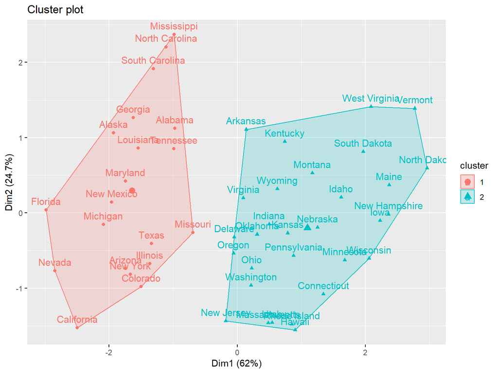

## Choosing $k$

- Dozens of methods have been proposed for determining the optimal number of clusters ($k$), we will discuss three of them:
  - The elbow method
  - The silhouette method
  - The gap statistic

## The Elbow Method

- The elbow method is simple and intuitive, it requires us to plot “Total Withiness” or “wss” versus the number of clusters and look for an “elbow”
  - By definition, wss will *always* decrease with $k$, but eventually these decreases become small
  - The “elbow” occurs where minimal improvement is seen when further increasing $k$
  - For the `USArrests` dataset, 2-4 clusters seems reasonable

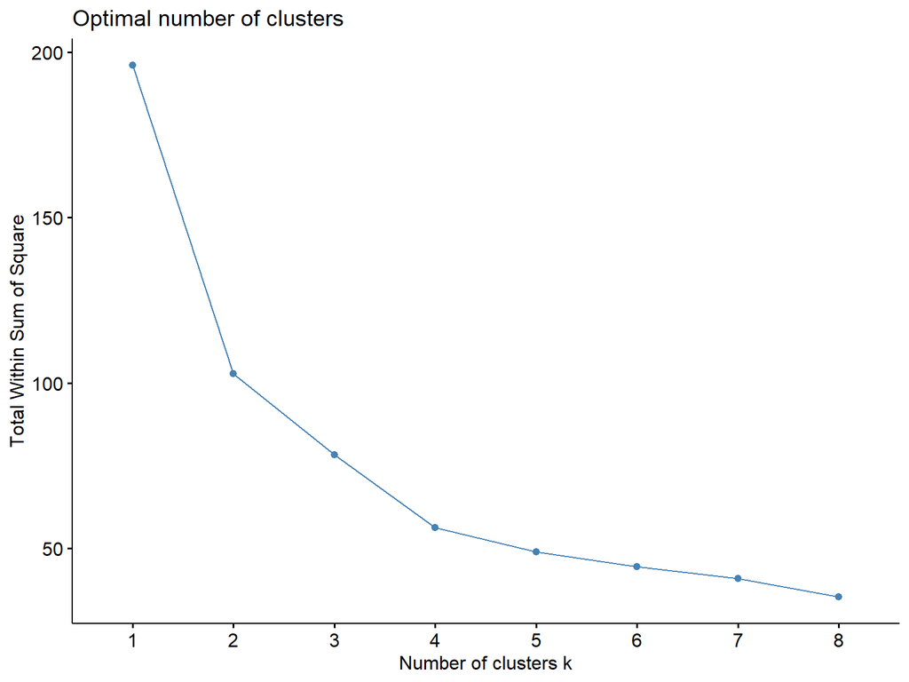

```r
## Standardize the data
USArrests_scaled <- scale(USArrests)

## Plot for the Elbow Method
fviz_nbclust(USArrests_scaled, kmeans, method = "wss", k.max = 8)
```

## The Silhouette Method

- The elbow method is somewhat subjective, whereas the *silhouette method* objectively calculates the **silhouette value** of each data-point
- In the silhouette method, a silhouette is calculated each data-point using the following steps:
1. For data-point $x_i$ belonging to cluster $C_k$, calculate the average distance to all other members of $C_k$, then call this value $a_i$
2. For each cluster not containing $x_i$, calculate the average distance between $x_i$ and the members of that cluster, then call the minimum of these distances $b_i$
3. Define the silhouette for $x_i$ as $s_i = (b_i - a_i)/max(a_i,b_i)$
- Silhouettes can range from -1 (a poor fit within the assigned cluster) to +1 (an excellent fit within the assigned cluster)
- Negative silhouettes are undesirable, they indicate a data-point is actually closer to the data-points in another cluster

## The Silhouette Method

- The *average silhouette value* can be used to determine the optimal $k$
- In the `USArrests` example, the method suggests $k = 2$ is optimal

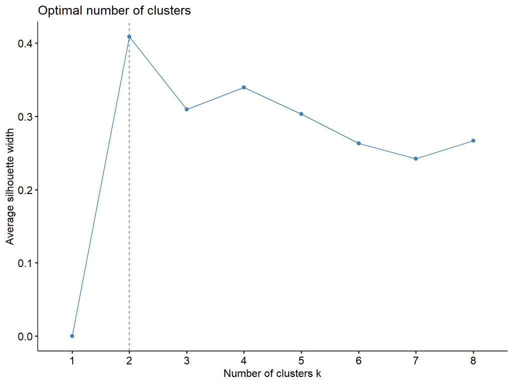

## The Silhouette Method

- Silhouettes are also useful to investigate how well individual data-points fit within their assigned cluster

```
##   cluster size ave.sil.width
## 1       1   20          0.37
## 2       2   30          0.43
```

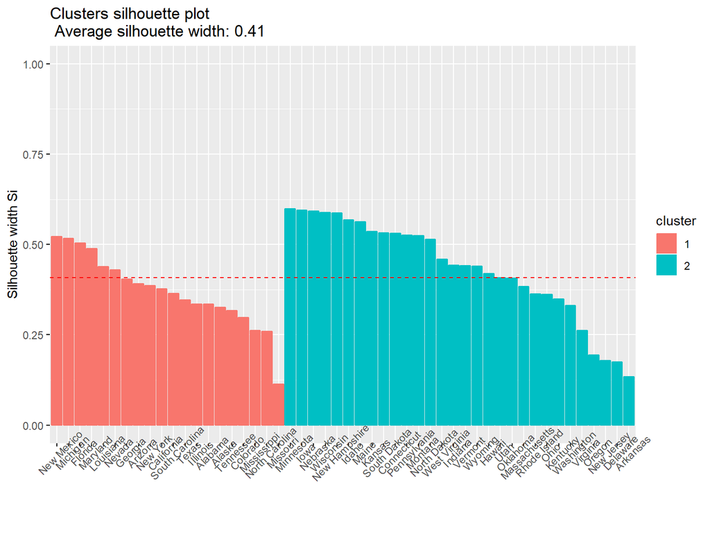

## The Gap Statistic

- As previously mentioned, “Total Withiness” always declines as $k$ increases
- The idea behind the gap statistic is to determine the expected “wss” for a given $k$, then look at the gap between the expected and observed “wss”
  - More specific details can be found in [this paper](https://statweb.stanford.edu/~gwalther/gap)
- Note that larger gap statistics are desirable, as they indicate the clusters are doing better than expected
- When using the gap statistic we should also consider the simple-to-complex principle
  - By default, `fviz_nbclust` will select the smallest $k$ within one standard error of the maximum

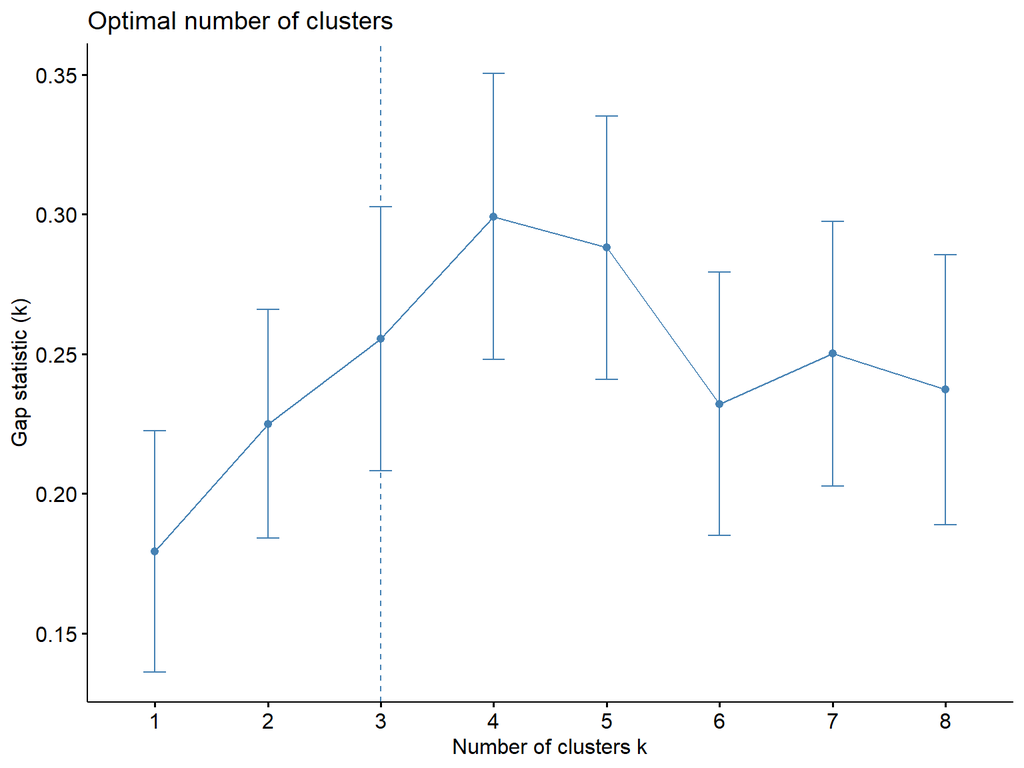

## Closing Remarks

- All of the results and examples in this presentation have used Euclidean distance, but many other distance measures exist, each with their own strengths and weaknesses
  - We won’t cover these measures in this course, but you’re welcome to explore them on the final project
- The next presentation will cover hierarchal clustering methods, as well as methods for accommodating categorical variables into our distance-based calculations